# Computational Finance (Part II): Assessing the Effectiveness of Hidden Markov Models in Algorithmic Trading

LBK

2025-06-30

# 1 Introduction

This report explores the application of **Hidden Markov Models (HMMs)** to regime detection in high-frequency EUR/USD data and evaluates their impact on algorithmic trading performance. The objective is to determine whether incorporating latent state information improves the profitability and stability of mean-reversion strategies.

# 2 Data and Preprocessing

```
##             EURUSD  EURCAD  EURJPY   EURGBP
## 2025-01-01 1.03534 1.48914 162.797 0.827471
## 2025-01-02 1.03180 1.48606 162.238 0.828854
## 2025-01-03 1.02883 1.48316 161.792 0.829328
## 2025-01-04 1.03092 1.48958 162.166 0.829885
## 2025-01-05 1.03088 1.48950 162.165 0.829849
## 2025-01-06 1.03598 1.48840 163.208 0.829773
## 2025-01-07 1.03835 1.48822 163.938 0.829458
## 2025-01-08 1.03226 1.48356 163.366 0.831833
## 2025-01-09 1.03046 1.48262 162.847 0.836997
## 2025-01-10 1.02751 1.48108 162.380 0.837985
```

# 3 Distributional Properties of Returns

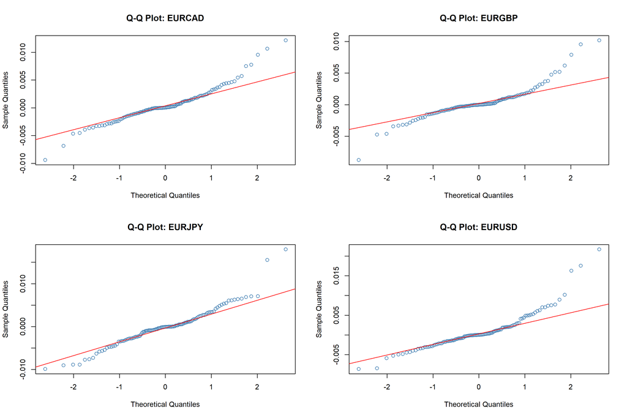

Figure 1. Q-Q Plots of EUR Cross Returns

These diagnostics indicate clear **non-normality** and **fat tails**, justifying the use of heavy-tailed emission distributions in the HMM framework.

# 4 Emission Distribution Specification

The emission density of each hidden state is modeled using the **Student-t distribution**, parameterized as follows:

$$f(y_t \mid S_t = j) =
\frac{\Gamma\left(\frac{\nu_j + 1}{2}\right)}{\sqrt{\nu_j
\pi}\,\Gamma\left(\frac{\nu_j}{2}\right)\sigma_j}
\left[1 + \frac{(y_t - \mu_j)^2}{\nu_j\sigma_j^2}\right]^{-\frac{\nu_j +
1}{2}}$$

where $\nu_j$ controls tail thickness. The Student-t distribution provides robustness to outliers and volatility clustering.

# 5 Model Configurations and Sojourn Distributions

To evaluate different persistence dynamics, we estimate models under varying **sojourn distributions** and **state counts**:

$$d_j \sim \begin{cases}
\text{Poisson}(\lambda_j + s), & \text{(shifted Poisson)} \\
\text{Gamma}(\alpha_j, \beta_j),\\
\text{Geometric}(p_j),
\end{cases}$$

This yields 9 configurations (3 sojourns × 3 values of $K \in \{2,3,4\}$).

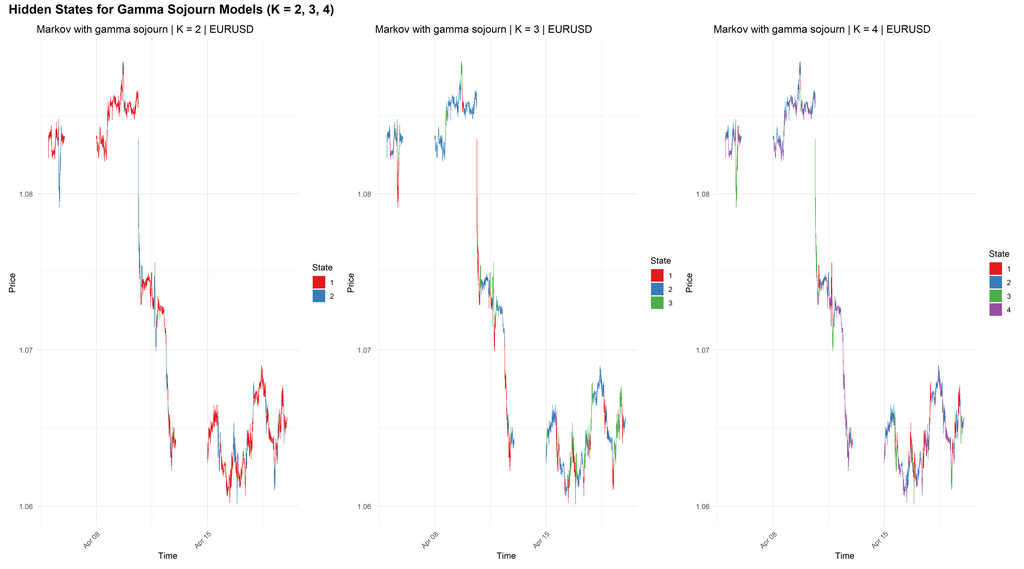

Figure 2. Comparison of Hidden States across K

# 6 Regime Dynamics and Transition Probabilities

We analyze persistence and regime-switching patterns. For a Markov chain with transition matrix $A = [a_{ij}]$, the expected duration in state $j$ is:

$$E[D_j] = \frac{1}{1 - a_{jj}}$$

```
##       Model State Visits Duration
## 1     gamma     1  19926    22.77
## 2     gamma     2  57128    80.92
## 3     gamma     3  21478    23.63
## 4   poisson     1  21186    23.28
## 5   poisson     2  58206    87.40
## 6   poisson     3  19140    22.52
## 7 geometric     1  19886    22.55
## 8 geometric     2  57179    81.22
## 9 geometric     3  21467    23.33
```

```
##
## --- Gamma SD ---
##       [,1]  [,2]  [,3]
## [1,] 0.000 0.382 0.618
## [2,] 0.476 0.000 0.524
## [3,] 0.581 0.419 0.000
##
## --- Poisson SD ---
##       [,1]  [,2]  [,3]
## [1,] 0.000 0.422 0.578
## [2,] 0.520 0.000 0.480
## [3,] 0.623 0.377 0.000
##
## --- Geometric SD ---
##       [,1]  [,2]  [,3]
## [1,] 0.955 0.017 0.028
## [2,] 0.006 0.987 0.007
## [3,] 0.025 0.018 0.957
```

# 7 Trading Strategy Implementation

We embed the decoded HMM regimes into a **mean-reversion breakout strategy** operating on 5-minute EUR/USD data.

### 7.0.1 Entry Rules

- Breakout trigger: close outside Bollinger Bands.
- Entry at 61.8% Fibonacci retracement of breakout candle.
- Trade direction aligned with SMA(200).
- HMM filter applied to restrict trading to specific states.

### 7.0.2 Exit Rules

- TP: mean reversion to SMA(20) or multiples thereof.
- SL: fixed 100 pips as protection.

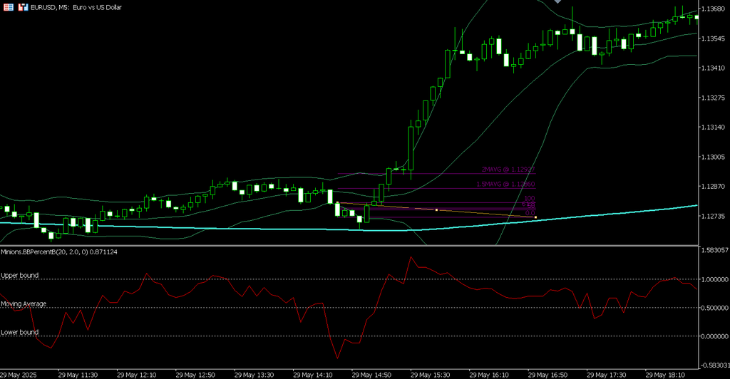

Figure 3. Trade Setup Example in MT5